# R- Programming Assignment Part B

Janki Mochampi

2023-05-09

# Introduction (EDA)

## Introduction(strategy)

Data Cleaning - I will evaluate the dataset for unnecessary columns,missing data and also rename columns where possible .Moreover in a situation where my datasets have similar columns I will combine them into a single dataset

Determine variable relationships - I will not only find out how independent variables relate to the dependent variable but also how independent variables relate to each other and I will visualize this relationships and perform simple linear regression(dependent variable vs independent variable) as well as multiple linear regression (dependent variable vs independent variables)

Importation and data loading

```r
library(ggplot2)
library(ggmap)
library(maps)
library(skimr)
library(dplyr)
library(caTools)
whr2019=read.csv("C:/Users/FBDA20-023/OneDrive - Botswana Accountancy College/Desktop/R happiness report/2019_report.csv")
whr2020=read.csv("C:/Users/FBDA20-023/OneDrive - Botswana Accountancy College/Desktop/R happiness report/2020_report.csv")
map = map_data("world")
```

## Summarizing numerical data

determining structure, dimensions and using head function to see how data looks like

```r
str(whr2019)
```

```
## 'data.frame':    138 obs. of  10 variables:
##  $ country          : chr  "Denmark" "Switzerland" "Iceland" "Norway" ...
##  $ happiness_score  : num  7.53 7.51 7.5 7.5 7.41 ...
##  $ gdp_per_capita   : num  1.44 1.53 1.43 1.58 1.41 ...
##  $ family           : num  1.16 1.15 1.18 1.13 1.13 ...
##  $ health           : num  0.795 0.863 0.867 0.796 0.811 ...
##  $ freedom          : num  0.579 0.586 0.566 0.596 0.571 ...
##  $ government_trust : num  0.445 0.412 0.15 0.358 0.41 ...
##  $ generosity       : num  0.362 0.281 0.477 0.379 0.255 ...
##  $ dystopia_residual: num  2.74 2.69 2.83 2.66 2.83 ...
##  $ continent        : chr  "Europe" "Europe" "Europe" "Europe" ...
```

```r
str(whr2020)
```

```
## 'data.frame':    138 obs. of  10 variables:
##  $ country          : chr  "Finland" "Denmark" "Switzerland" "Iceland" ...
##  $ happiness_score  : num  7.81 7.65 7.56 7.5 7.49 ...
##  $ gdp_per_capita   : num  1.29 1.33 1.39 1.33 1.42 ...
##  $ social_support   : num  1.5 1.5 1.47 1.55 1.5 ...
##  $ health           : num  0.961 0.979 1.041 1.001 1.008 ...
##  $ freedom          : num  0.662 0.665 0.629 0.662 0.67 ...
##  $ generosity       : num  0.16 0.243 0.269 0.362 0.288 ...
##  $ government_trust : num  0.478 0.495 0.408 0.145 0.434 ...
##  $ dystopia_residual: num  2.76 2.43 2.35 2.46 2.17 ...
##  $ continent        : chr  "Europe" "Europe" "Europe" "Europe" ...
```

```r
dim(whr2019)
```

```
## [1] 138  10
```

```r
dim(whr2020)
```

```
## [1] 138  10
```

```r
head(whr2019)
```

|  | country | happiness_score | gdp_per_capita | family | health | freedom | government_trust | generosity | dystopia_residual | continent |
| --- | --- | --- | --- | --- | --- | --- | --- | --- | --- | --- |
| 1 | Denmark | 7.526 | 1.44178 | 1.16374 | 0.79504 | 0.57941 | 0.44453 | 0.36171 | 2.73939 | Europe |
| 2 | Switzerland | 7.509 | 1.52733 | 1.14524 | 0.86303 | 0.58557 | 0.41203 | 0.28083 | 2.69463 | Europe |
| 3 | Iceland | 7.501 | 1.42666 | 1.18326 | 0.86733 | 0.56624 | 0.14975 | 0.47678 | 2.83137 | Europe |
| 4 | Norway | 7.498 | 1.57744 | 1.12690 | 0.79579 | 0.59609 | 0.35776 | 0.37895 | 2.66465 | Europe |
| 5 | Finland | 7.413 | 1.40598 | 1.13464 | 0.81091 | 0.57104 | 0.41004 | 0.25492 | 2.82596 | Europe |
| 6 | Canada | 7.404 | 1.44015 | 1.09610 | 0.82760 | 0.57370 | 0.31329 | 0.44834 | 2.70485 | North America |

```r
head(whr2020)
```

|  | country | happiness_score | gdp_per_capita | social_support | health | freedom | generosity | government_trust | dystopia_residual | continent |
| --- | --- | --- | --- | --- | --- | --- | --- | --- | --- | --- |
| 1 | Finland | 7.8087 | 1.285190 | 1.499526 | 0.9612714 | 0.6623167 | 0.1596704 | 0.4778573 | 2.762835 | Europe |
| 2 | Denmark | 7.6456 | 1.326949 | 1.503449 | 0.9793326 | 0.6650399 | 0.2427934 | 0.4952603 | 2.432741 | Europe |
| 3 | Switzerland | 7.5599 | 1.390774 | 1.472403 | 1.0405332 | 0.6289545 | 0.2690558 | 0.4079459 | 2.350267 | Europe |
| 4 | Iceland | 7.5045 | 1.326502 | 1.547567 | 1.0008434 | 0.6619807 | 0.3623302 | 0.1445408 | 2.460688 | Europe |
| 5 | Norway | 7.4880 | 1.424207 | 1.495173 | 1.0080719 | 0.6702009 | 0.2879851 | 0.4341006 | 2.168266 | Europe |
| 6 | Netherlands | 7.4489 | 1.338946 | 1.463646 | 0.9756753 | 0.6136265 | 0.3363176 | 0.3685698 | 2.352117 | Europe |

Selecting numerical variables from both datasets

```r
numeric_19<- select(whr2019,c(2,3,4,5,6,7,8))
numeric_20<- select(whr2020,c(2,3,4,5,6,7,8))
```

Finally we use the summary function to find the summary of numeric variables

```r
summary(numeric_19)
```

```
##  happiness_score gdp_per_capita        family           health
##  Min.   :2.905   Min.   :0.05661   Min.   :0.0000   Min.   :0.0000
##  1st Qu.:4.407   1st Qu.:0.67472   1st Qu.:0.6423   1st Qu.:0.4097
##  Median :5.351   Median :1.03235   Median :0.8609   Median :0.6161
##  Mean   :5.409   Mean   :0.95958   Mean   :0.8052   Mean   :0.5668
##  3rd Qu.:6.347   3rd Qu.:1.27435   3rd Qu.:1.0326   3rd Qu.:0.7300
##  Max.   :7.526   Max.   :1.69752   Max.   :1.1833   Max.   :0.9472
##     freedom       government_trust    generosity
##  Min.   :0.0432   Min.   :0.00000   Min.   :0.0000
##  1st Qu.:0.2587   1st Qu.:0.05518   1st Qu.:0.1446
##  Median :0.3913   Median :0.09586   Median :0.2148
##  Mean   :0.3719   Mean   :0.13258   Mean   :0.2367
##  3rd Qu.:0.4722   3rd Qu.:0.17387   3rd Qu.:0.3032
##  Max.   :0.6085   Max.   :0.50521   Max.   :0.8197
```

```r
summary(numeric_20)
```

```
##  happiness_score gdp_per_capita   social_support       health
##  Min.   :2.567   Min.   :0.0000   Min.   :0.3524   Min.   :0.1087
##  1st Qu.:4.775   1st Qu.:0.6033   1st Qu.:1.0037   1st Qu.:0.5374
##  Median :5.551   Median :0.9380   Median :1.2197   Median :0.7666
##  Mean   :5.551   Mean   :0.8837   Mean   :1.1705   Mean   :0.7106
##  3rd Qu.:6.299   3rd Qu.:1.1866   3rd Qu.:1.3935   3rd Qu.:0.8647
##  Max.   :7.809   Max.   :1.5367   Max.   :1.5476   Max.   :1.1378
##     freedom         generosity     government_trust
##  Min.   :0.0000   Min.   :0.0000   Min.   :0.00000
##  1st Qu.:0.3816   1st Qu.:0.1143   1st Qu.:0.05729
##  Median :0.4934   Median :0.1705   Median :0.09736
##  Mean   :0.4693   Mean   :0.1872   Mean   :0.13201
##  3rd Qu.:0.5852   3rd Qu.:0.2552   3rd Qu.:0.16298
##  Max.   :0.6933   Max.   :0.5698   Max.   :0.53316
```

## Anomalies in Numerical data Investigation

I started by dropping dystopia _residual which is unnecessary column in this investigation

There are no missing values in the datasets

Finally I renamed social support to family so that I could concatenate whr2019 and whr2020

```r
#dropping unneccessary column
whr2019 <- subset (whr2019, select = -dystopia_residual)


whr2020 <- subset (whr2020, select = -dystopia_residual)


# finding the number of missing values in datasets
sum(is.na(whr2019))
```

```
## [1] 0
```

```r
sum(is.na(whr2020))
```

```
## [1] 0
```

```r
#Concatenating the datasets to whr 2019-2020
colnames(whr2020)[which(names(whr2020)== "social_support")]<- "family"

whr<- rbind(whr2019,whr2020)
```

## Visualization between variables relations

Combining the datasets requires the datasets to have similar structure and column names

```r
# Correlation matrix for numerical variables rounded to 1 decimal place

cordata = whr[,c(2,3,4,5,6,7,8)]
corr <- round(cor(cordata), 1)
corr
```

```
##                  happiness_score gdp_per_capita family health freedom
## happiness_score              1.0            0.8    0.7    0.8     0.5
## gdp_per_capita               0.8            1.0    0.5    0.8     0.3
## family                       0.7            0.5    1.0    0.7     0.5
## health                       0.8            0.8    0.7    1.0     0.5
## freedom                      0.5            0.3    0.5    0.5     1.0
## government_trust             0.4            0.3    0.2    0.3     0.5
## generosity                   0.1            0.0   -0.1   -0.1     0.3
##                  government_trust generosity
## happiness_score               0.4        0.1
## gdp_per_capita                0.3        0.0
## family                        0.2       -0.1
## health                        0.3       -0.1
## freedom                       0.5        0.3
## government_trust              1.0        0.3
## generosity                    0.3        1.0
```

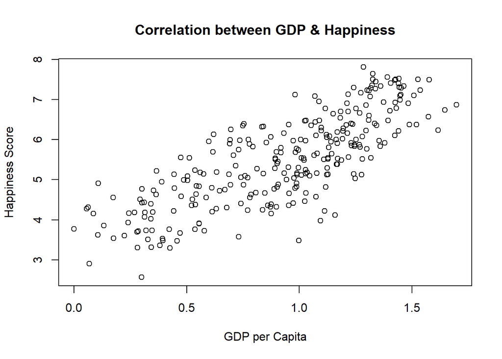

```r
plot(whr$gdp_per_capita,whr$happiness_score, main="Correlation between GDP & Happiness", xlab='GDP per Capita', ylab="Happiness Score")
```

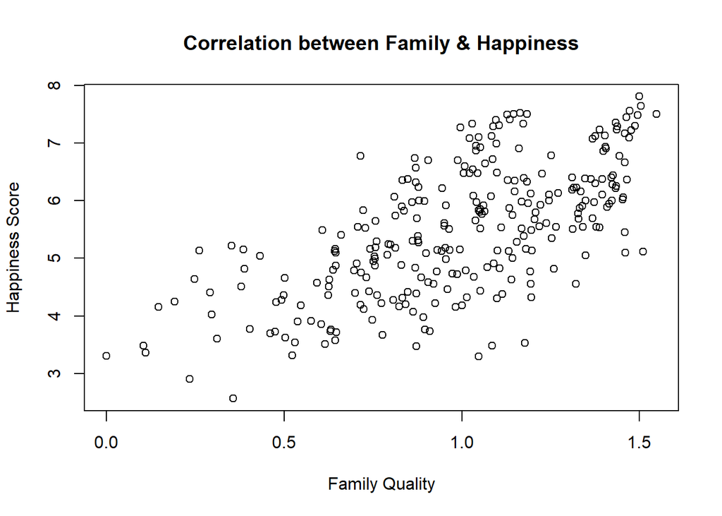

```r
plot(whr$family,whr$happiness_score, main="Correlation between Family & Happiness", xlab='Family Quality', ylab="Happiness Score")
```

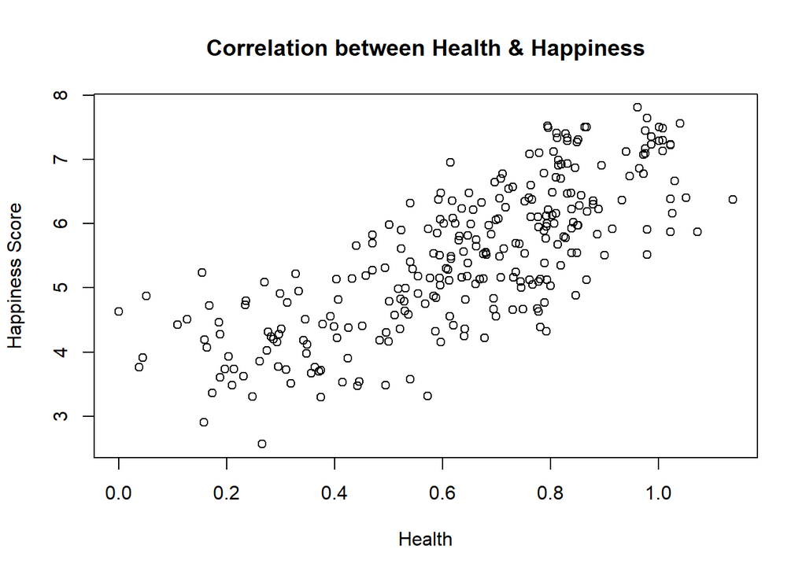

```r
plot(whr$health,whr$happiness_score, main="Correlation between Health & Happiness", xlab='Health', ylab="Happiness Score")
```

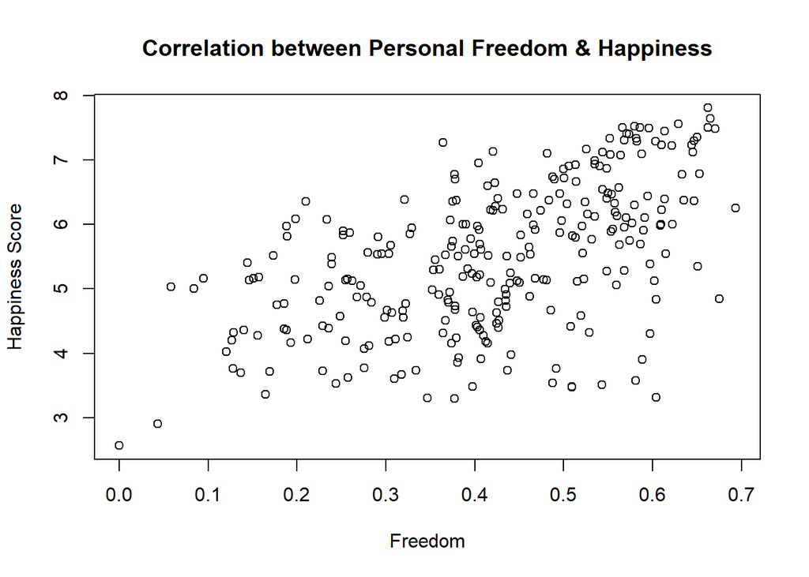

```r
plot(whr$freedom,whr$happiness_score, main="Correlation between Personal Freedom & Happiness", xlab='Freedom', ylab="Happiness Score")
```

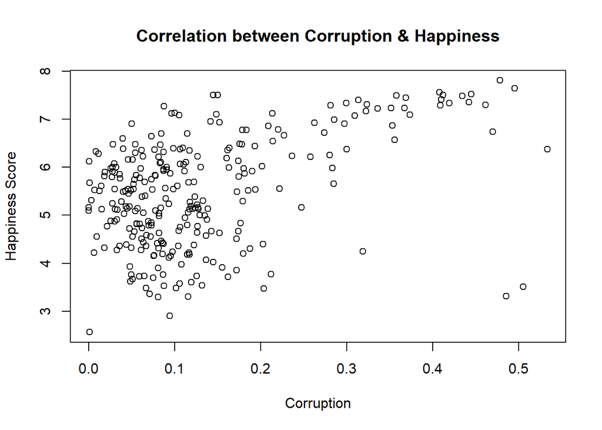

```r
plot(whr$government_trust,whr$happiness_score, main="Correlation between Corruption & Happiness", xlab='Corruption', ylab="Happiness Score")
```

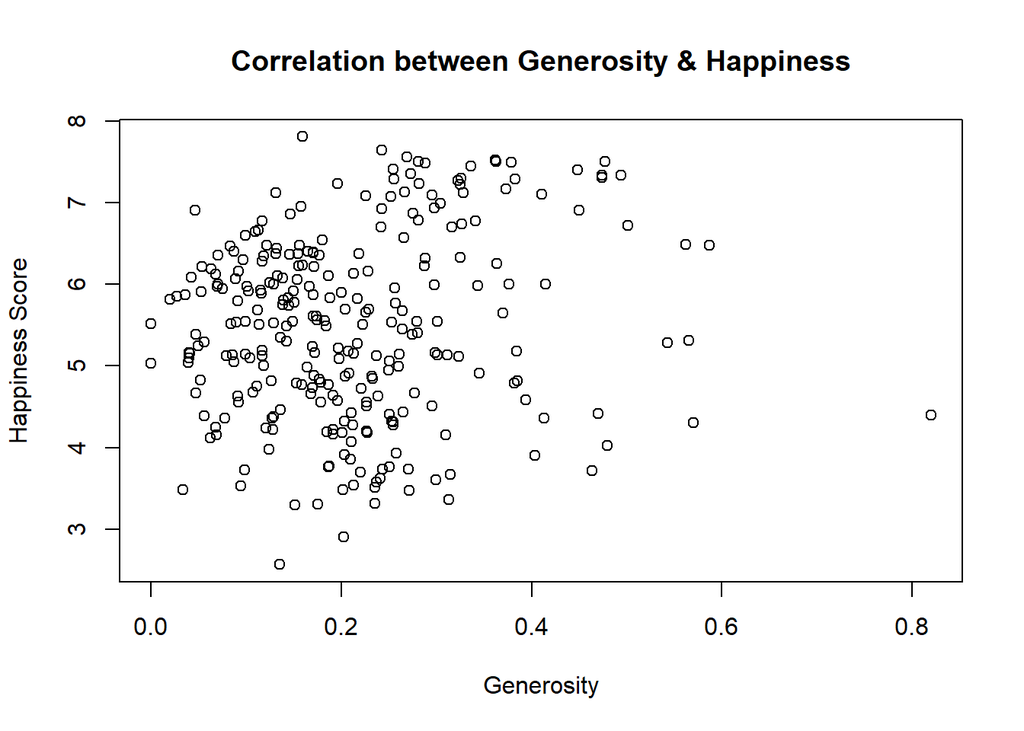

```r
plot(whr$generosity,whr$happiness_score, main="Correlation between Generosity & Happiness", xlab='Generosity', ylab="Happiness Score")
```

# Simple Linear Regression

## Evaluation of variable relations

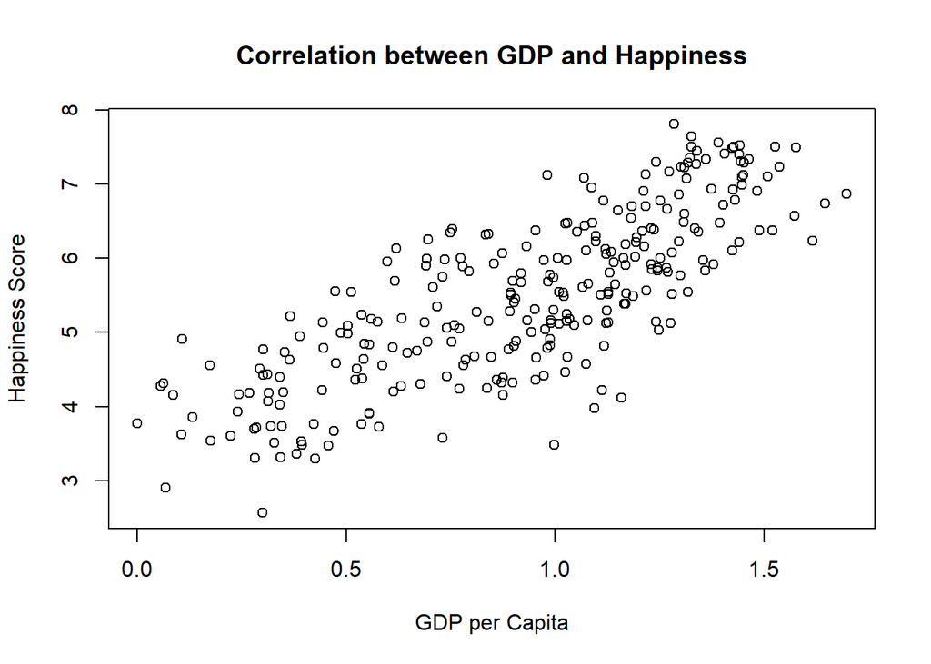

```r
#Checking for linear relationship between variables
plot(whr$gdp_per_capita,whr$happiness_score, main = 'Correlation between GDP and Happiness',xlab='GDP per Capita', ylab="Happiness Score")
```

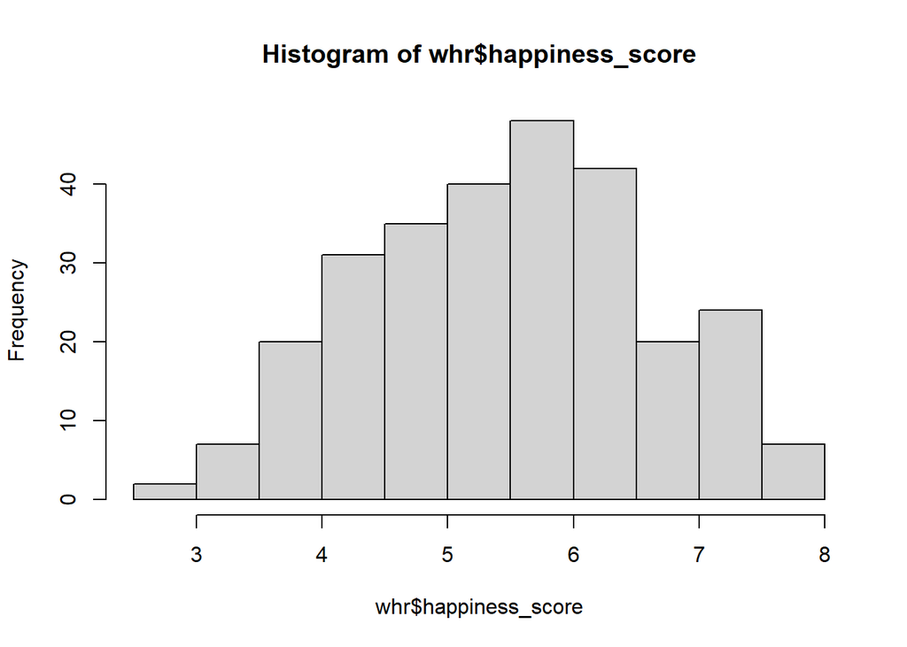

```r
# Checking if Dependent variable here follows a normal distribution
# And i found out that it does
hist(whr$happiness_score)
```

## Model Definition

```r
split = sample.split(whr$happiness_score, SplitRatio = 0.7)
trainingset = subset(whr, split == TRUE)
testset = subset(whr, split == FALSE)

# Fitting Simple Linear Regression to the Training set
lm.r= lm(formula = happiness_score ~ gdp_per_capita,
         data = trainingset)
```

## Statistical Inference

```r
coef(lm.r)
```

```
##    (Intercept) gdp_per_capita
##       3.383581       2.260095
```

```r
summary(lm.r)
```

```
##
## Call:
## lm(formula = happiness_score ~ gdp_per_capita, data = trainingset)
##
## Residuals:
##      Min       1Q   Median       3Q      Max
## -2.15924 -0.54724  0.02752  0.57156  1.52047
##
## Coefficients:
##                Estimate Std. Error t value Pr(>|t|)
## (Intercept)      3.3836     0.1320   25.64   <2e-16 ***
## gdp_per_capita   2.2601     0.1326   17.05   <2e-16 ***
## ---
## Signif. codes:  0 '***' 0.001 '**' 0.01 '*' 0.05 '.' 0.1 ' ' 1
##
## Residual standard error: 0.7074 on 191 degrees of freedom
## Multiple R-squared:  0.6034, Adjusted R-squared:  0.6014
## F-statistic: 290.6 on 1 and 191 DF,  p-value: < 2.2e-16
```

Y-intercept that is the value of dependent variable when independent variable is 0 is approximately 3.38

## Prediction

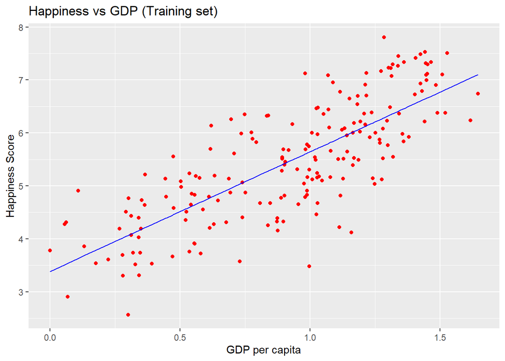

```r
# Predicting the Test set results
ypred = predict(lm.r, newdata = testset)

# Visualising the Training set results

ggplot() + geom_point(aes(x = trainingset$gdp_per_capita,
                          y = trainingset$happiness_score), colour = 'red') +
  geom_line(aes(x = trainingset$gdp_per_capita,
                y = predict(lm.r, newdata = trainingset)), colour = 'blue') +

  ggtitle('Happiness vs GDP (Training set)') +
  xlab('GDP per capita') +
  ylab('Happiness Score')
```

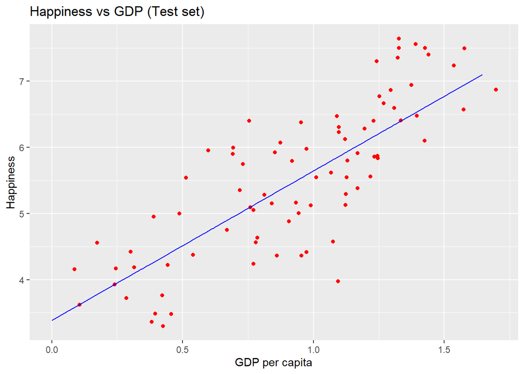

```r
# Visualising the Test set results

ggplot() +
  geom_point(aes(x = testset$gdp_per_capita, y = testset$happiness_score),
             colour = 'red') +
  geom_line(aes(x = trainingset$gdp_per_capita,
                y = predict(lm.r, newdata = trainingset)),
            colour = 'blue') +
  ggtitle('Happiness vs GDP (Test set)') +
  xlab('GDP per capita') +
  ylab('Happiness')
```

# Multiple Linear Regression

## Evaluation of variables

```r
#  test the relationship between  independent variables

numeric_whr<- select(whr,c(3,4,5,6,7,8))
cor(numeric_whr)
```

```
##                  gdp_per_capita      family      health   freedom
## gdp_per_capita       1.00000000  0.53859386  0.77360942 0.3316494
## family               0.53859386  1.00000000  0.69847732 0.5461696
## health               0.77360942  0.69847732  1.00000000 0.4506499
## freedom              0.33164938  0.54616955  0.45064991 1.0000000
## government_trust     0.34536281  0.20215922  0.31111325 0.4605171
## generosity          -0.02637441 -0.06119783 -0.06198609 0.2532587
##                  government_trust  generosity
## gdp_per_capita          0.3453628 -0.02637441
## family                  0.2021592 -0.06119783
## health                  0.3111132 -0.06198609
## freedom                 0.4605171  0.25325868
## government_trust        1.0000000  0.26506421
## generosity              0.2650642  1.00000000
```

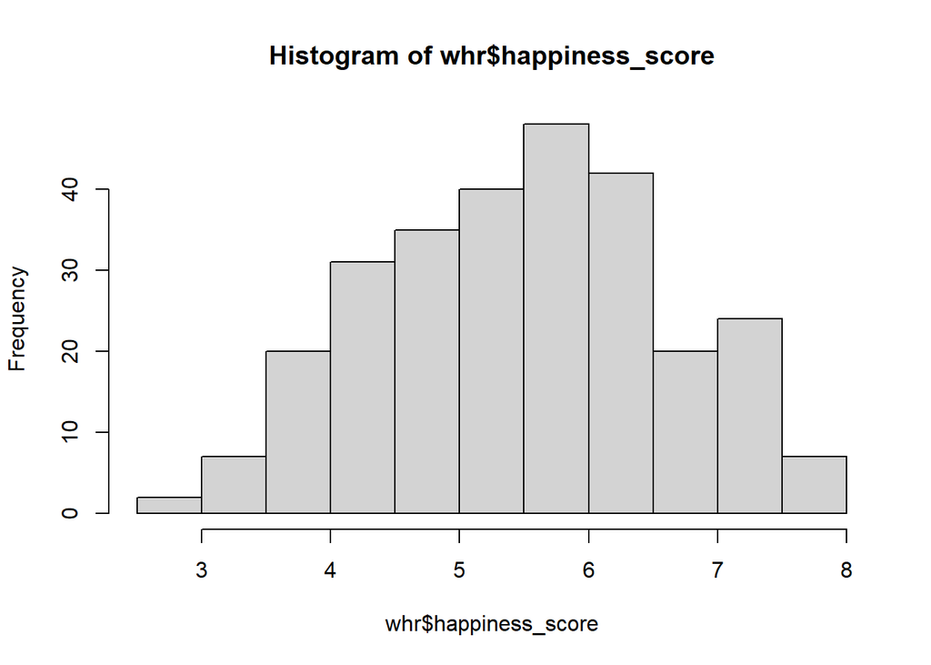

```r
#test whether your dependent variable follows a normal distribution.


hist(whr$happiness_score)
```

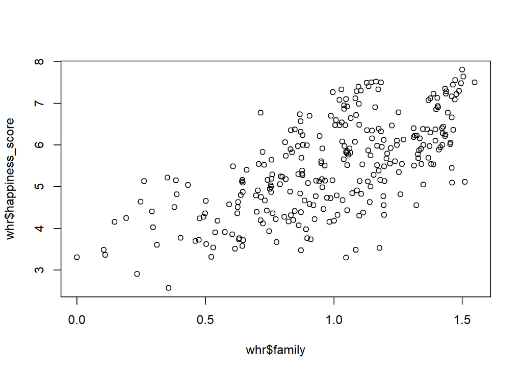

```r
#Check for Linearity

plot(whr$happiness_score ~ whr$family, data=whr)
```

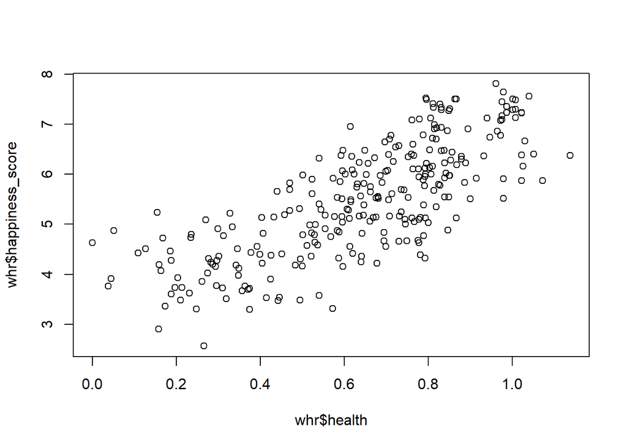

```r
plot(whr$happiness_score ~ whr$health, data=whr)
```

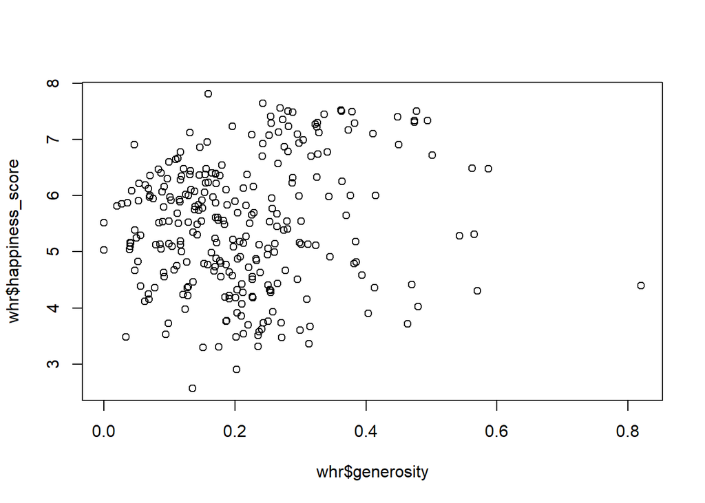

```r
plot(whr$happiness_score ~ whr$generosity, data=whr)
```

## Summary form Evaluation of variables

```r
# Go ahead with multiple linear regression

multi_lm<-lm(whr$happiness_score ~ family + generosity + health, data = whr)

summary(multi_lm)
```

```
##
## Call:
## lm(formula = whr$happiness_score ~ family + generosity + health,
##     data = whr)
##
## Residuals:
##      Min       1Q   Median       3Q      Max
## -1.82987 -0.44047 -0.03329  0.46673  1.58778
##
## Coefficients:
##             Estimate Std. Error t value Pr(>|t|)
## (Intercept)   2.4801     0.1556  15.937  < 2e-16 ***
## family        0.8661     0.1748   4.955 1.27e-06 ***
## generosity    1.6926     0.3371   5.021 9.30e-07 ***
## health        2.7955     0.2365  11.821  < 2e-16 ***
## ---
## Signif. codes:  0 '***' 0.001 '**' 0.01 '*' 0.05 '.' 0.1 ' ' 1
##
## Residual standard error: 0.6763 on 272 degrees of freedom
## Multiple R-squared:  0.6438, Adjusted R-squared:  0.6399
## F-statistic: 163.9 on 3 and 272 DF,  p-value: < 2.2e-16
```

Y-intercept that is the value of dependent variable when independent variables is 0 is approximately 2.5

The F-statistic too far from 1 that is 163.9 which means there is a linear relationship between variables

The model fits actual data by approximately 63.99%(We use Adjusted R-squared)

# References

https://www.geeksforgeeks.org/simple-linear-regression-using-r/ https://www.statology.org/exploratory-data-analysis-in-r/ https://dzchilds.github.io/eda-for-bio/exploring-categorical-variables.html https://datatofish.com/multiple-linear-regression-in-r/ https://www.scribbr.com/statistics/linear-regression-in-r/